# Results Interpretation and Narrative Synthesis

Where are the hotspots, who is affected, and what are the drivers?

Author

Jerónimo Rodríguez Escobar

Published

May 18, 2026

## 1 Overview

This document synthesizes the primary outputs of the Global NCP hotspot analysis. It loads the final summary tables to build a narrative around the three core questions of the project:

1. **Where are the hotspots?** We identify the geographic distribution, intensity, and overlap of ES hotspots.
2. **Who is affected?** We profile the socioeconomic characteristics of the populations living within these hotspots.
3. **What are the drivers?** We attribute ES decline to specific land cover change dynamics.

The goal is to move from quantitative tables to qualitative insights for the final manuscript.

## 2 Setup

## 3 Load Synthesized Data

This section loads the three key data products generated by the upstream analysis notebooks.

```
Loaded area stats.
```

```
Loaded population exposure stats.
```

```
Loaded LCC attribution stats.
```

```
Loaded KS test results.
```

```
Loaded multi-service stats.
```

## 4 Part 1: Where are the hotspots? (Geographic Concentration)

This section uses `hotspot_area_stats.csv` and `hotspot_multiservice_stats.csv` to identify the regions and biomes bearing a disproportionate burden of ecosystem service decline. Hotspots of ecosystem service decline are not randomly distributed; they cluster heavily in the Global South, creating epicenters of **Compound Risk** where communities face multiple simultaneous ecological failures.

### 4.1 Key Questions:

- Which regions/biomes have the highest **Hotspot Intensity** (i.e., largest percentage of their own area in crisis)?
- Which regions/biomes contain the largest **Global Share** of hotspots for each service?
- Which regions/biomes show the highest **Relative Intensity**, indicating a disproportionate burden?
- Where are multi-service hotspots concentrated (high **“Hotness”**)?

### 4.2 Analysis: Hotspot Concentration by Grouping

#### 4.2.1 Top World Bank Region by Relative Hotspot Intensity

| Service | Top Region | Relative Intensity |
| --- | --- | --- |
| C_Risk | Sub-Saharan Africa | 4.20 |
| C_Risk_Red_Ratio | Sub-Saharan Africa | 4.18 |
| N_Ret_Ratio | Europe & Central Asia | 1.56 |
| N_export | Sub-Saharan Africa | 1.68 |
| Nature_Access | Sub-Saharan Africa | 1.55 |
| Pollination | Sub-Saharan Africa | 2.04 |
| Sed_Ret_Ratio | Sub-Saharan Africa | 2.03 |
| Sed_export | Sub-Saharan Africa | 1.52 |

#### 4.2.2 Top WWF Biome by Relative Hotspot Intensity

| Service | Top Biome | Relative Intensity |
| --- | --- | --- |
| C_Risk | Temperate Grasslands, Savannas & Shrublands | 1.49 |
| C_Risk_Red_Ratio | Temperate Grasslands, Savannas & Shrublands | 1.49 |
| N_Ret_Ratio | Temperate Grasslands, Savannas & Shrublands | 1.33 |
| N_export | Temperate Grasslands, Savannas & Shrublands | 1.58 |
| Nature_Access | Temperate Grasslands, Savannas & Shrublands | 2.14 |
| Pollination | Temperate Grasslands, Savannas & Shrublands | 2.00 |
| Sed_Ret_Ratio | Temperate Grasslands, Savannas & Shrublands | 1.71 |
| Sed_export | Temperate Grasslands, Savannas & Shrublands | 2.22 |

#### 4.2.3 Top Income Group by Relative Hotspot Intensity

| Service | Top Income Group | Relative Intensity |
| --- | --- | --- |
| C_Risk | 5. Low income | 3.23 |
| C_Risk_Red_Ratio | 5. Low income | 3.24 |
| N_Ret_Ratio | 5. Low income | 1.60 |
| N_export | 5. Low income | 1.74 |
| Nature_Access | 5. Low income | 1.56 |
| Pollination | 5. Low income | 2.19 |
| Sed_Ret_Ratio | 5. Low income | 2.18 |
| Sed_export | 5. Low income | 1.69 |

#### 4.2.4 Top 10 Countries by Relative Hotspot Intensity (excluding smallest 10% by area)

Top 10 Countries by Relative Hotspot Intensity

| Service | Country | Relative Intensity |
| --- | --- | --- |
| C_Risk | Kiribati | 28.40 |
| C_Risk | Liberia | 26.29 |
| C_Risk | Laos | 17.52 |
| C_Risk | Madagascar | 15.04 |
| C_Risk | Sri Lanka | 14.49 |
| C_Risk | Mexico | 10.85 |
| C_Risk | Togo | 10.24 |
| C_Risk | Georgia | 9.79 |
| C_Risk | Cambodia | 7.93 |
| C_Risk | Republic of the Congo | 7.38 |
| C_Risk_Red_Ratio | Kiribati | 28.58 |
| C_Risk_Red_Ratio | Liberia | 26.58 |
| C_Risk_Red_Ratio | Laos | 18.35 |
| C_Risk_Red_Ratio | Madagascar | 14.97 |
| C_Risk_Red_Ratio | Sri Lanka | 14.58 |
| C_Risk_Red_Ratio | Mexico | 10.79 |
| C_Risk_Red_Ratio | Togo | 10.30 |
| C_Risk_Red_Ratio | Georgia | 9.86 |
| C_Risk_Red_Ratio | Cambodia | 7.64 |
| C_Risk_Red_Ratio | Republic of the Congo | 7.26 |
| N_Ret_Ratio | Guatemala | 4.81 |
| N_Ret_Ratio | Haiti | 4.40 |
| N_Ret_Ratio | Switzerland | 4.19 |
| N_Ret_Ratio | Vietnam | 4.00 |
| N_Ret_Ratio | Fiji | 3.96 |
| N_Ret_Ratio | Honduras | 3.86 |
| N_Ret_Ratio | Kiribati | 3.63 |
| N_Ret_Ratio | Palau | 3.59 |
| N_Ret_Ratio | Ivory Coast | 3.58 |
| N_Ret_Ratio | South Africa | 3.37 |
| N_export | Guatemala | 6.01 |
| N_export | Switzerland | 5.04 |
| N_export | Fiji | 4.91 |
| N_export | South Africa | 4.36 |
| N_export | Vietnam | 4.25 |
| N_export | Dominica | 3.74 |
| N_export | Burundi | 3.70 |
| N_export | Costa Rica | 3.68 |
| N_export | Seychelles | 3.45 |
| N_export | eSwatini | 3.42 |
| Nature_Access | Costa Rica | 7.56 |
| Nature_Access | Azerbaijan | 6.89 |
| Nature_Access | Moldova | 4.78 |
| Nature_Access | Haiti | 4.40 |
| Nature_Access | Guatemala | 4.27 |
| Nature_Access | Liberia | 4.18 |
| Nature_Access | Honduras | 3.80 |
| Nature_Access | Dominica | 3.74 |
| Nature_Access | Ivory Coast | 3.71 |
| Nature_Access | Dominican Republic | 3.66 |
| Pollination | Moldova | 5.94 |
| Pollination | Fiji | 5.12 |
| Pollination | eSwatini | 4.88 |
| Pollination | Guatemala | 4.81 |
| Pollination | New Zealand | 4.66 |
| Pollination | Kyrgyzstan | 4.33 |
| Pollination | Ethiopia | 4.30 |
| Pollination | Tajikistan | 4.25 |
| Pollination | Liberia | 4.24 |
| Pollination | Costa Rica | 4.17 |
| Sed_Ret_Ratio | Benin | 8.86 |
| Sed_Ret_Ratio | Guatemala | 7.93 |
| Sed_Ret_Ratio | Costa Rica | 6.62 |
| Sed_Ret_Ratio | Burundi | 6.32 |
| Sed_Ret_Ratio | Fiji | 4.91 |
| Sed_Ret_Ratio | Haiti | 4.17 |
| Sed_Ret_Ratio | Moldova | 4.05 |
| Sed_Ret_Ratio | eSwatini | 3.90 |
| Sed_Ret_Ratio | Bangladesh | 3.64 |
| Sed_Ret_Ratio | United Republic of Tanzania | 3.56 |
| Sed_export | Costa Rica | 6.66 |
| Sed_export | Cuba | 6.18 |
| Sed_export | Turkmenistan | 6.12 |
| Sed_export | Guatemala | 6.01 |
| Sed_export | New Zealand | 4.53 |
| Sed_export | Tajikistan | 4.22 |
| Sed_export | Dominican Republic | 4.21 |
| Sed_export | Bolivia | 4.03 |
| Sed_export | Fiji | 3.82 |
| Sed_export | Dominica | 3.74 |

#### 4.2.5 Top Regions & Biomes by Multi-service Hotspots (‘Hotness’)

Top 5 Regions/Biomes by Average Number of Overlapping Hotspots

| Grouping | Group | Mean Hotspots |
| --- | --- | --- |
| WWF_biome | Temperate Grasslands, Savannas & Shrublands | 0.51 |
| WWF_biome | Tropical & Subtropical Moist Broadleaf Forests | 0.24 |
| WWF_biome | Temperate Conifer Forests | 0.13 |
| region_wb | Sub-Saharan Africa | 0.52 |
| region_wb | Europe & Central Asia | 0.36 |
| region_wb | Latin America & Caribbean | 0.31 |
| region_wb | North America | 0.27 |
| region_wb | East Asia & Pacific | 0.27 |

#### 4.2.6 Top 10 Countries by Multi-service Hotspots (‘Hotness’) (excluding smallest 10% by area)

Top 10 Countries by Average Number of Overlapping Hotspots

| Country | Mean Hotspots |
| --- | --- |
| Guatemala | 1.54 |
| Costa Rica | 1.39 |
| Liberia | 1.27 |
| Fiji | 1.16 |
| Kiribati | 1.07 |
| Moldova | 0.92 |
| Cuba | 0.88 |
| New Zealand | 0.81 |
| Burundi | 0.78 |
| Dominican Republic | 0.77 |

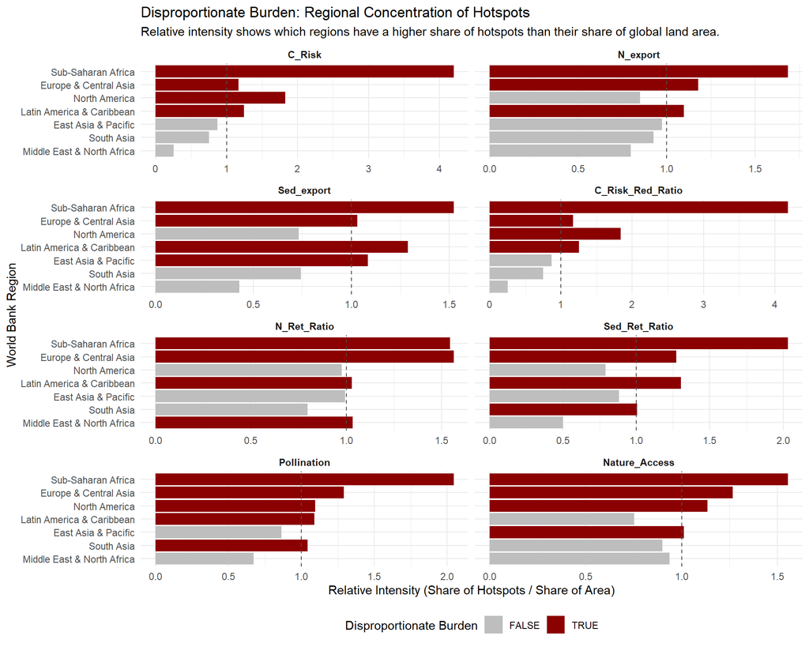

Relative intensity of hotspots by World Bank Region. A value greater than 1 indicates a region has a disproportionately high share of global hotspots compared to its land area.

## 5 Part 2: Who is affected? (Socioeconomic Exposure)

This section uses `hotspot_pop_exposure.csv` to quantify the human dimension of ES degradation.

### 5.1 Key Questions:

- How many people are living in hotspot areas for each service?
- What is the **absolute** exposure across different income groups? (Total number of people affected).
- What is the **relative** socioeconomic profile of hotspot areas? (Are hotspots statistically richer/poorer, more/less populated than the background landscape?).

### 5.2 Analysis 1: Relative Socioeconomic Profile (KS Tests)

#### 5.2.1 Profile by Population

Socioeconomic Profile of Hotspots: Population

| Service | Cliff’s Delta | P-value (adj) |
| --- | --- | --- |
| C_Risk | 0.522 | 0 |
| C_Risk_Red_Ratio | 0.541 | 0 |
| N_Ret_Ratio | 0.473 | 0 |
| N_export | 0.657 | 0 |
| Nature_Access | 0.623 | 0 |
| Pollination | 0.678 | 0 |
| Sed_Ret_Ratio | 0.644 | 0 |
| Sed_export | 0.584 | 0 |

#### 5.2.2 Profile by GDP

Socioeconomic Profile of Hotspots: GDP

| Service | Cliff’s Delta | P-value (adj) |
| --- | --- | --- |
| C_Risk | 0.553 | 0 |
| C_Risk_Red_Ratio | 0.568 | 0 |
| N_Ret_Ratio | 0.486 | 0 |
| N_export | 0.654 | 0 |
| Nature_Access | 0.607 | 0 |
| Pollination | 0.674 | 0 |
| Sed_Ret_Ratio | 0.657 | 0 |
| Sed_export | 0.580 | 0 |

#### 5.2.3 Profile by HDI

Socioeconomic Profile of Hotspots: HDI

| Service | Cliff’s Delta | P-value (adj) |
| --- | --- | --- |
| C_Risk | 0.277 | 0 |
| C_Risk_Red_Ratio | 0.247 | 0 |
| N_Ret_Ratio | 0.200 | 0 |
| N_export | -0.005 | 0 |
| Nature_Access | -0.061 | 0 |
| Pollination | -0.058 | 0 |
| Sed_Ret_Ratio | 0.179 | 0 |
| Sed_export | -0.090 | 0 |

#### 5.2.4 Profile by Gini

Socioeconomic Profile of Hotspots: Gini

| Service | Cliff’s Delta | P-value (adj) |
| --- | --- | --- |
| C_Risk | 0.070 | 0 |
| C_Risk_Red_Ratio | 0.073 | 0 |
| N_Ret_Ratio | -0.158 | 0 |
| N_export | 0.223 | 0 |
| Nature_Access | 0.213 | 0 |
| Pollination | 0.293 | 0 |
| Sed_Ret_Ratio | -0.092 | 0 |
| Sed_export | 0.293 | 0 |

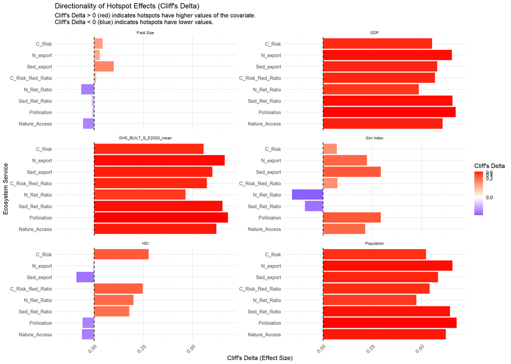

Directionality of socioeconomic effects in hotspots. Positive values (red) indicate hotspots have higher values of the variable (e.g., higher GDP, more population) than the background. Negative values (blue) indicate the opposite.

### 5.3 Analysis 2: Absolute Population Exposure

**Narrative Point:** The socioeconomic story is two-sided. The KS tests reveal the *relative* profile of hotspot areas (e.g., they tend to have higher GDP than the background), but analyzing absolute population numbers tells a different story about the *scale* of human impact. The vast majority of people exposed to ES decline reside not in high-income nations, but in Upper and Lower Middle-Income countries. This highlights the difference between the *character* of a location where decline occurs and the *scale* of its human impact.

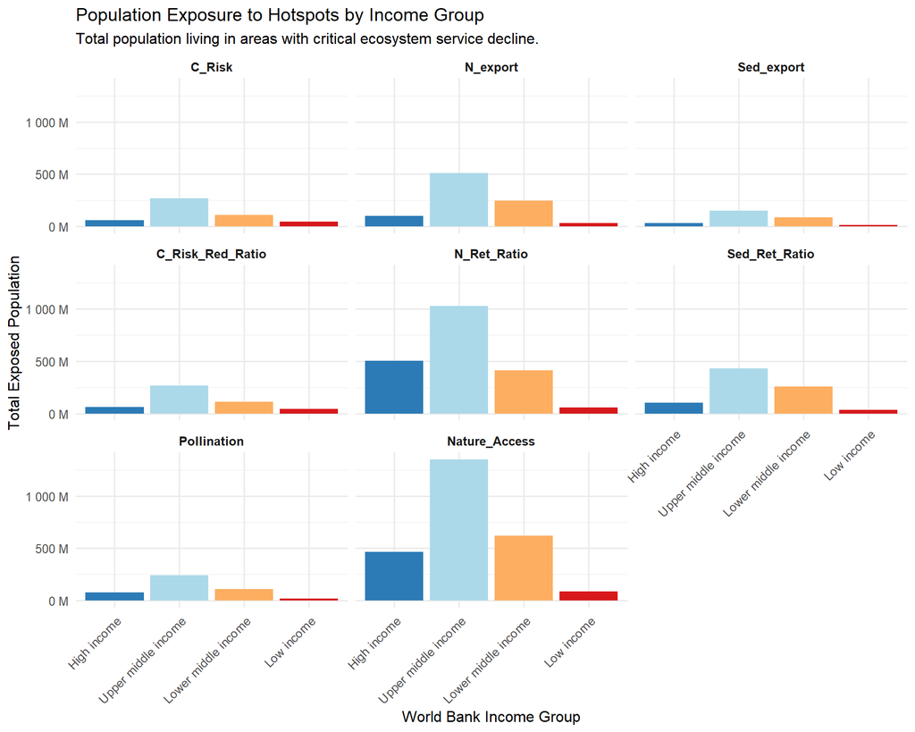

Total population living within ecosystem service hotspots, broken down by World Bank income group.

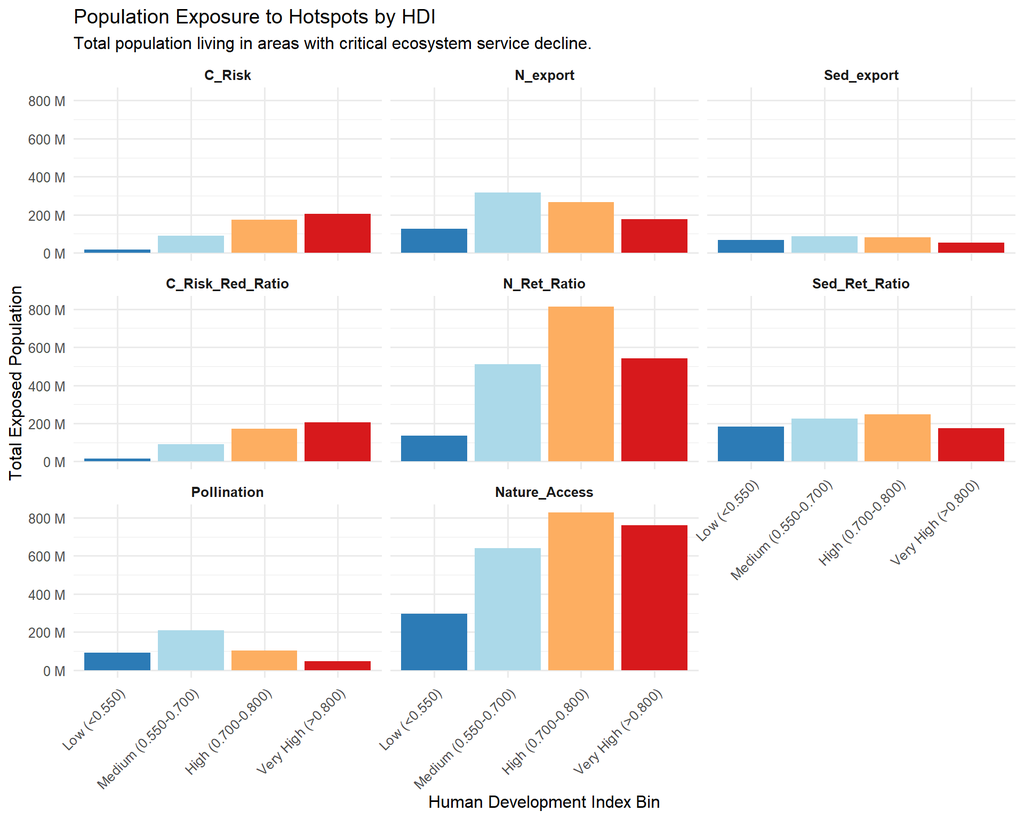

Absolute population exposure in hotspots, by Human Development Index (HDI) bin.

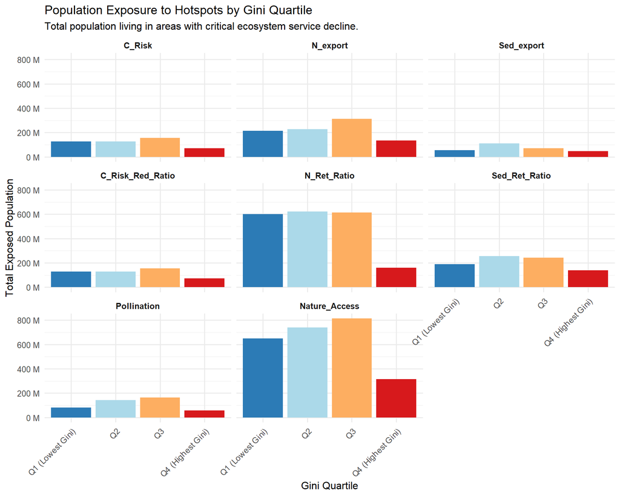

Absolute population exposure in hotspots, by Gini Quartile.

## 6 Part 3: What are the drivers? (LCC Attribution)

This section uses the `lcc_es_hotspot_overlap_pct.csv` table to connect ES hotspots to specific land cover change dynamics (e.g., Forest Loss, Cropland Expansion). The plot below shows the percentage of each service’s hotspot area that can be attributed to a major land conversion driver occurring in the same 10km grid cell.

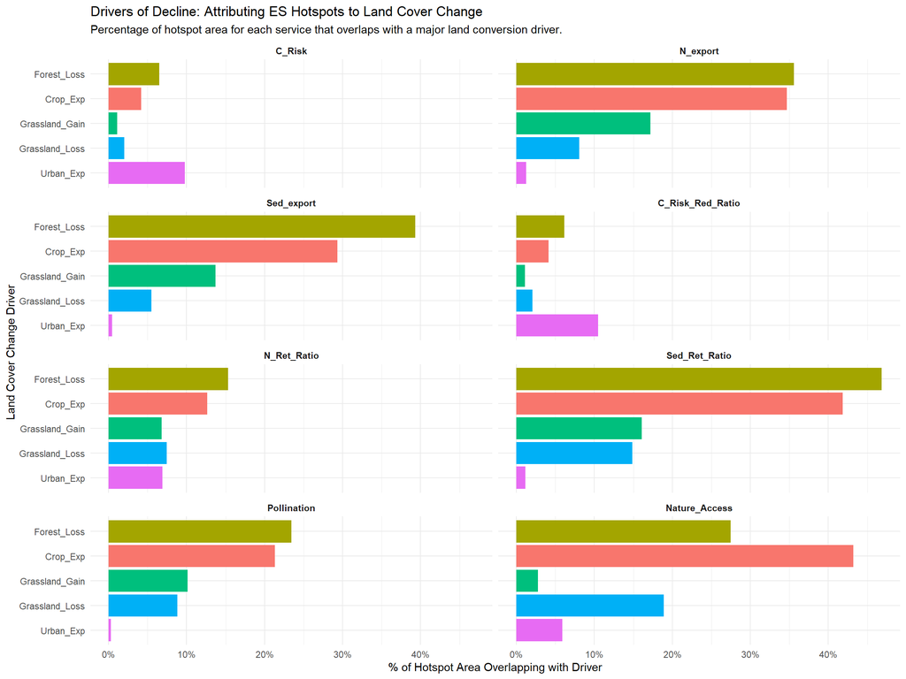

Percentage of ecosystem service hotspots attributed to different land cover change drivers.